# lab5

Derek Maldonado

3/16/2021

## Question 1

Consider a design with 3 groups, and 10 people per group. Assume that the dependent variable is assumed to be normally distributed, and use unit normal distributions with mean = 0, and sd = 1 in your simulations

Create simulated data for the above design that could be produced by the null hypothesis, and that results in a F value that is smaller than the critical value for F in this design (assume alpha = .05). Report the ANOVA, and show a ggplot of the means in the simulated data. Furthermore, display the individual data points on top of the means. Would you reject the null hypothesis in this situation, and would you be incorrect or correct in rejecting the null?

```r
library(tibble)
```

```r
library(ggplot2)
levels <- 3
numba <- 10


critF <- qf(0.95,2,27)

saveF <- length(3000)
for(i in 1:3000){
     dataq1 <- tibble(subjects = 1:(levels*numba),
                IV = as.factor(rep(1:levels, each = numba)),
                DV = rnorm(levels* numba, 0, 1)
               )
     ano <- aov(DV ~ IV, data=dataq1)
     simF <- summary(ano)[[1]]$'F value'

     if(simF < critF) break
     saveF[i] <- simF
}
summary(ano)
```

```
##             Df Sum Sq Mean Sq F value Pr(>F)
## IV           2  0.221  0.1105   0.135  0.875
## Residuals   27 22.147  0.8203
```

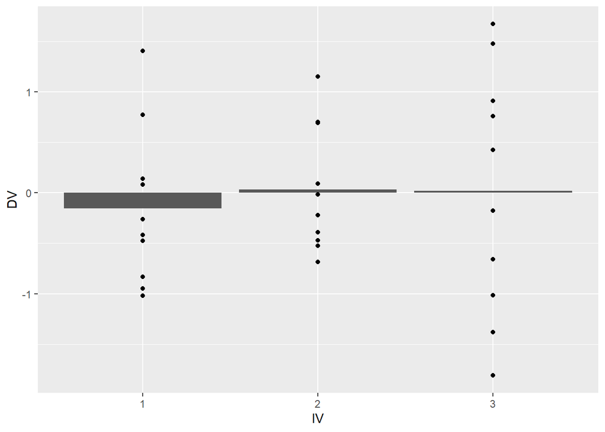

```r
ggplot(dataq1, aes(x=IV, y=DV))+
        geom_bar(stat = "summary", fun = "mean")+
        geom_point()
```

I would not reject the null hypothesis in this situation, and I would be correct in not rejecting it, since our F value is well below the critical value, and that is expected from a normal distribution.

## Question 2

Create simulated data for the above design that could be produced by the null hypothesis, and that results in a F value that is larger than the critical value for F in this design (assume alpha = .05). Report the ANOVA, and show a ggplot of the means in the simulated data. Furthermore, display the individual data points on top of the means. Would you reject the null hypothesis in this situation, and would you be incorrect or correct in rejecting the null?

```r
library(tibble)
library(ggplot2)

levels <- 3
numba <- 10


critF <- qf(0.95,2,27)

saveF <- length(30000)
for(i in 1:30000){
     dataq1 <- tibble(subjects = 1:(levels*numba),
                IV = as.factor(rep(1:levels, each = numba)),
                DV = rnorm(levels* numba, 0, 1)
               )
     ano <- aov(DV ~ IV, data=dataq1)
     simF <- summary(ano)[[1]]$'F value'

     if(simF > critF) break
}
i
```

```
## [1] 4
```

```r
summary(ano)
```

```
##             Df Sum Sq Mean Sq F value Pr(>F)
## IV           2  5.054  2.5270   3.695 0.0381 *
## Residuals   27 18.464  0.6838
## ---
## Signif. codes:  0 '***' 0.001 '**' 0.01 '*' 0.05 '.' 0.1 ' ' 1
```

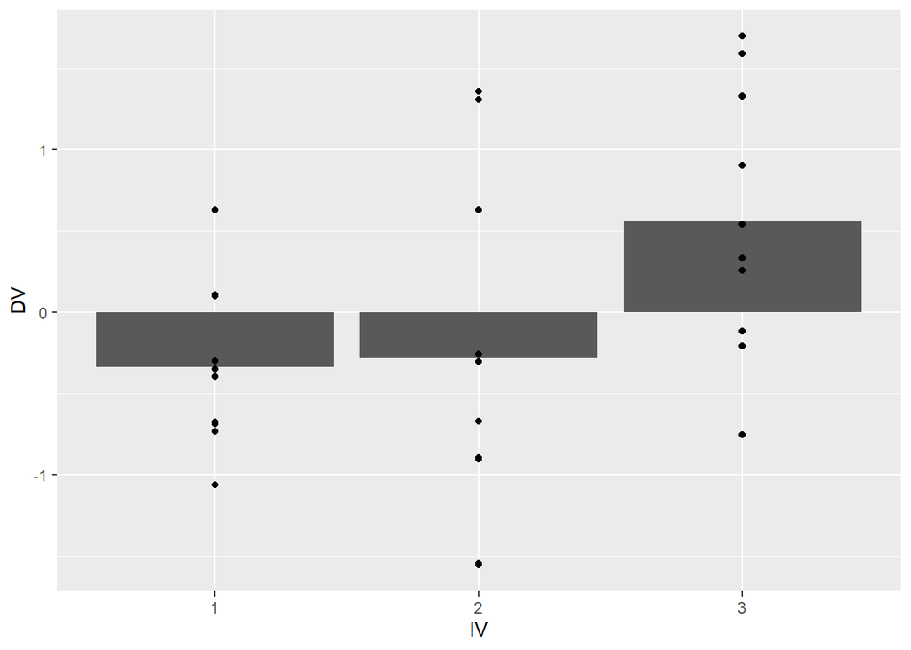

```r
ggplot(dataq1, aes(x=IV, y=DV))+
        geom_bar(stat = "summary", fun = "mean")+
        geom_point()
```